# Diversity measures

### Divergences between timepoint, including time normalised

Now we are interested in those divergences between single intervals across the patients both as a total value and also normalised by time (divergence month<sup>-1</sup>).

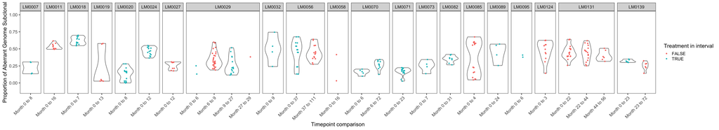

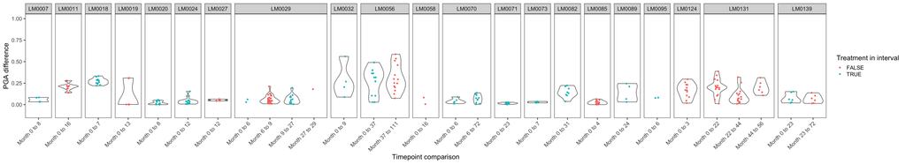

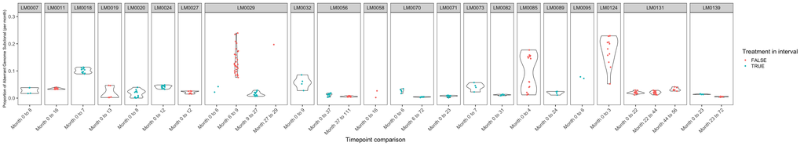

### Inter-timepoint divergence categorised by treatment status

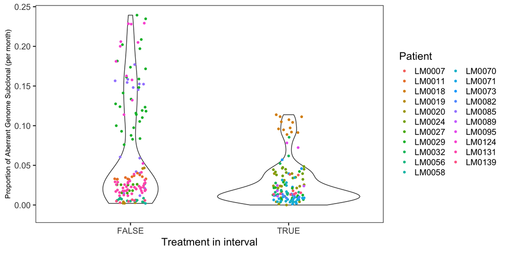

### Quick check of the spread of data in the treated and untreated categories

This plot is just a quick check of whether divergence by time, interval length and the treatment categories are well mixed.

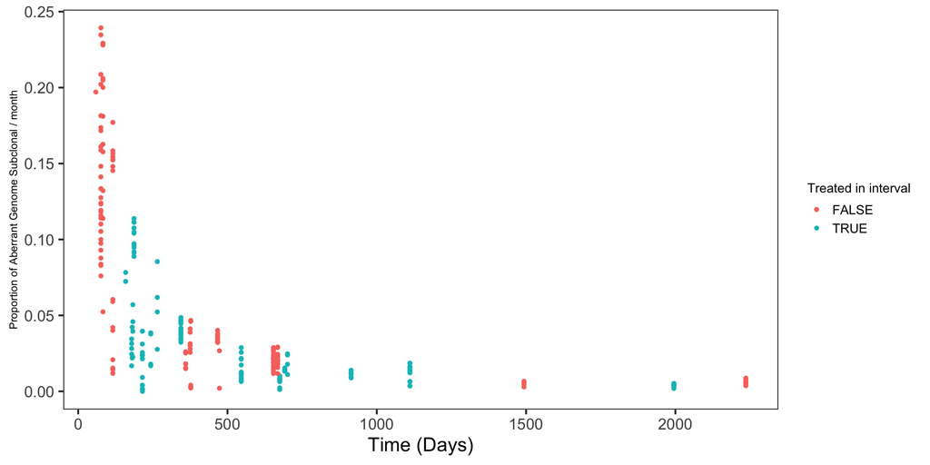

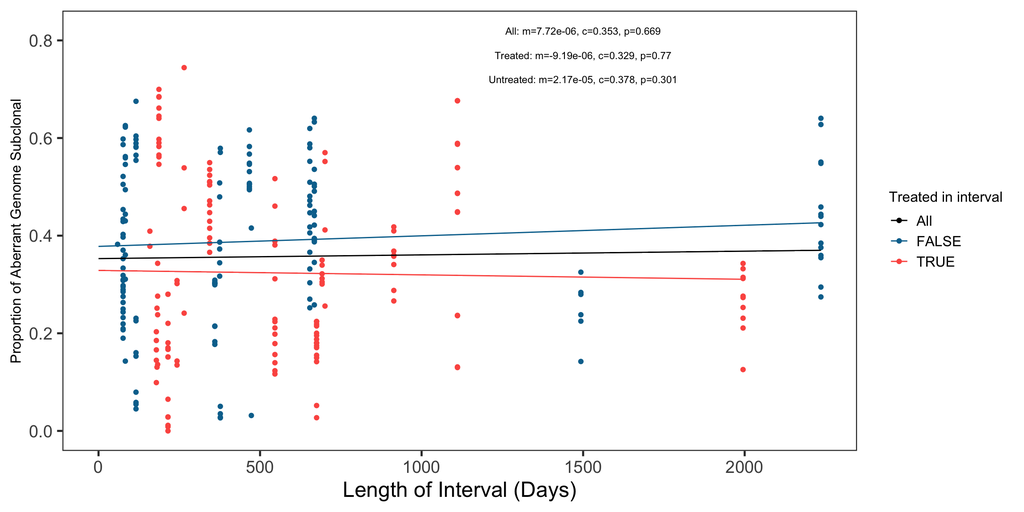

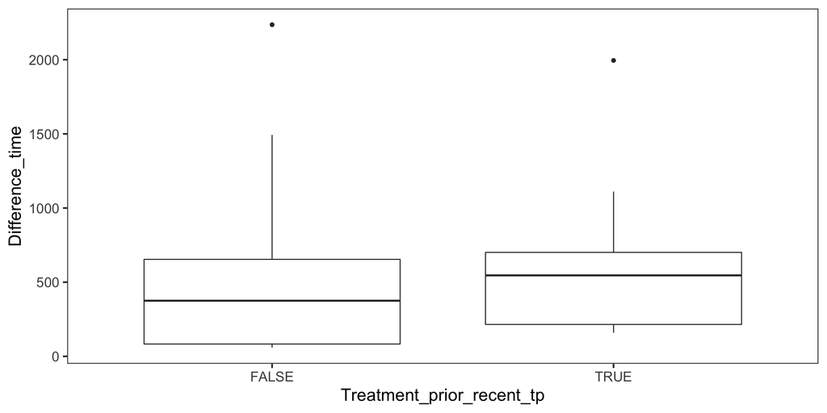

### Mixed model of non-time normalised divergence on and off treatment

Here we perform a mixed model to test if absolute differences in divergence are different between treatments, using patients as a random effect.

```
## [1] "Mixed model (3) - Divergence NOT normalised by time in treated and non-treated intervals using patients as random intercepts"
```

```
## Linear mixed model fit by REML. t-tests use Satterthwaite's method [
## lmerModLmerTest]
## Formula: dist ~ Treatment_prior_recent_tp + (1 | Patient)
##    Data: patient_dists_next_tp
##
## REML criterion at convergence: -314.3
##
## Scaled residuals:
##      Min       1Q   Median       3Q      Max
## -2.62854 -0.58391  0.03167  0.54471  2.76561
##
## Random effects:
##  Groups   Name        Variance Std.Dev.
##  Patient  (Intercept) 0.01625  0.1275
##  Residual             0.01538  0.1240
## Number of obs: 280, groups:  Patient, 21
##
## Fixed effects:
##                                Estimate Std. Error        df t value
## (Intercept)                     0.36935    0.03301  28.74310   11.19
## Treatment_prior_recent_tpTRUE  -0.03345    0.02535 254.04584   -1.32
##                               Pr(>|t|)
## (Intercept)                   5.45e-12 ***
## Treatment_prior_recent_tpTRUE    0.188
## ---
## Signif. codes:  0 '***' 0.001 '**' 0.01 '*' 0.05 '.' 0.1 ' ' 1
##
## Correlation of Fixed Effects:
##             (Intr)
## Trtm___TRUE -0.446
```

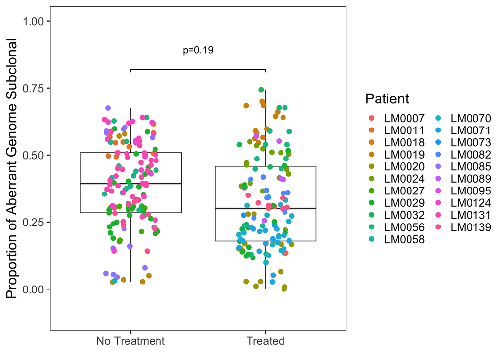

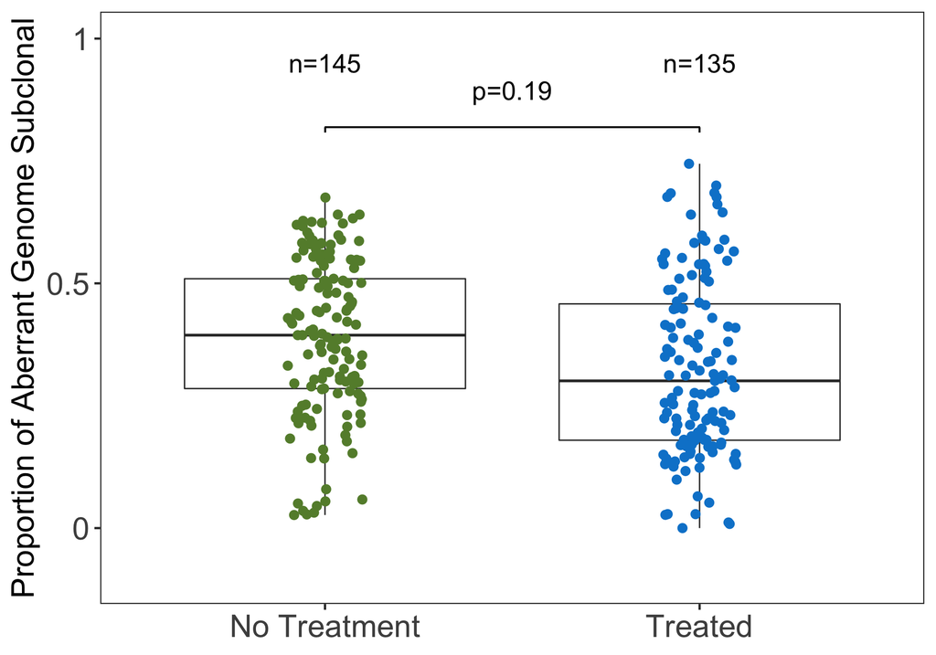

```
## [1] "Repeat of mixed model (3) but for PGA difference"
```

```
## Linear mixed model fit by REML. t-tests use Satterthwaite's method [
## lmerModLmerTest]
## Formula: pdiff ~ Treatment_prior_recent_tp + (1 | Patient)
##    Data: patient_dists_next_tp
##
## REML criterion at convergence: -556.6
##
## Scaled residuals:
##     Min      1Q  Median      3Q     Max
## -3.1979 -0.4008 -0.0861  0.3390  3.8891
##
## Random effects:
##  Groups   Name        Variance Std.Dev.
##  Patient  (Intercept) 0.007379 0.08590
##  Residual             0.006398 0.07999
## Number of obs: 280, groups:  Patient, 21
##
## Fixed effects:
##                                 Estimate Std. Error         df t value
## (Intercept)                     0.117287   0.022008  28.770477   5.329
## Treatment_prior_recent_tpTRUE  -0.009647   0.016443 259.484664  -0.587
##                               Pr(>|t|)
## (Intercept)                   1.04e-05 ***
## Treatment_prior_recent_tpTRUE    0.558
## ---
## Signif. codes:  0 '***' 0.001 '**' 0.01 '*' 0.05 '.' 0.1 ' ' 1
##
## Correlation of Fixed Effects:
##             (Intr)
## Trtm___TRUE -0.434
```

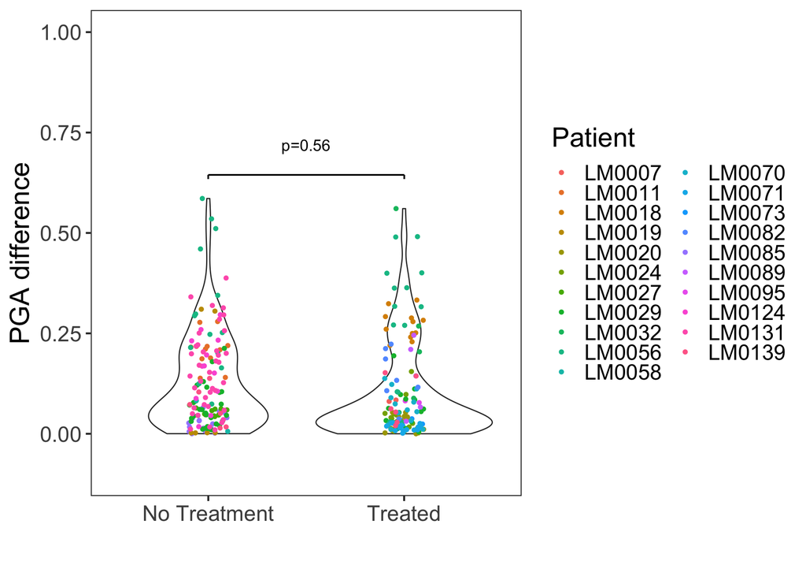

### Mixed model of time normalised divergence on and off treatment

Here we perform a mixed model to test if time normalised differences in divergence are different between treatments, using patients as a random effect.

```
## [1] "Mixed model (4) - Divergence over time in treated and non-treated intervals using patients as random intercepts"
```

```
## Linear mixed model fit by REML. t-tests use Satterthwaite's method [
## lmerModLmerTest]
## Formula: Divergence_by_time ~ Treatment_prior_recent_tp + (1 | Patient)
##    Data: patient_dists_next_tp
##
## REML criterion at convergence: -1065.6
##
## Scaled residuals:
##     Min      1Q  Median      3Q     Max
## -3.7577 -0.3250 -0.0178  0.2930  3.9637
##
## Random effects:
##  Groups   Name        Variance  Std.Dev.
##  Patient  (Intercept) 0.0019302 0.04393
##  Residual             0.0009906 0.03147
## Number of obs: 280, groups:  Patient, 21
##
## Fixed effects:
##                                 Estimate Std. Error         df t value
## (Intercept)                     0.075433   0.010661  25.143229   7.075
## Treatment_prior_recent_tpTRUE  -0.055020   0.006652 276.127632  -8.271
##                               Pr(>|t|)
## (Intercept)                   1.98e-07 ***
## Treatment_prior_recent_tpTRUE 5.68e-15 ***
## ---
## Signif. codes:  0 '***' 0.001 '**' 0.01 '*' 0.05 '.' 0.1 ' ' 1
##
## Correlation of Fixed Effects:
##             (Intr)
## Trtm___TRUE -0.364
```

### Time normalised timepoint divergence averaged per patient

Here we just make a plot of time normalised divergence between timepoints average in each time point.

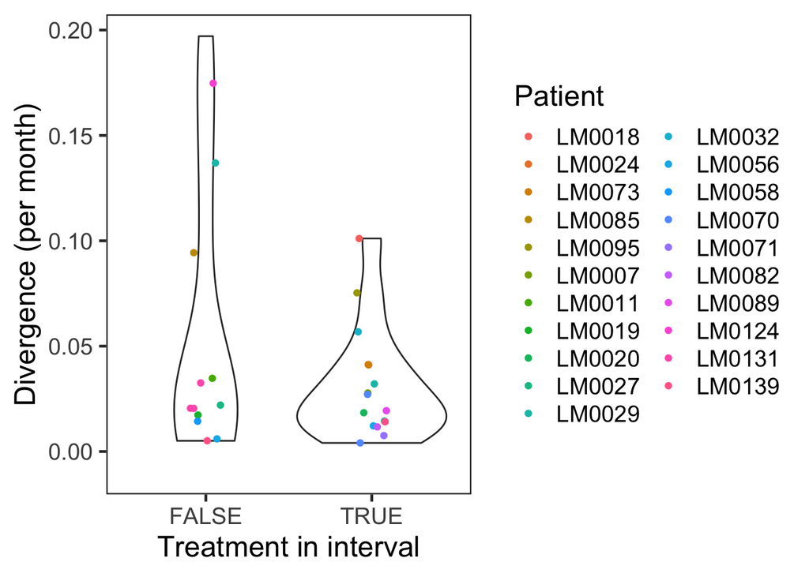

### Average change in PGA across timepoints

Here we process the data to calculate percentage of the genome aberrated (PGA) and to compare from one timepoint to the next whether this goes up or down and record the difference. Here is PGA in one sample is 0.41 and in the next it is 0.43, we would report it as going up by 0.02 * 100 (2). We average this for each timepoint and report the median of the averages across the cohort.

```
## [1] "Median mean increase in PGA (+ / -): 7.7"
```

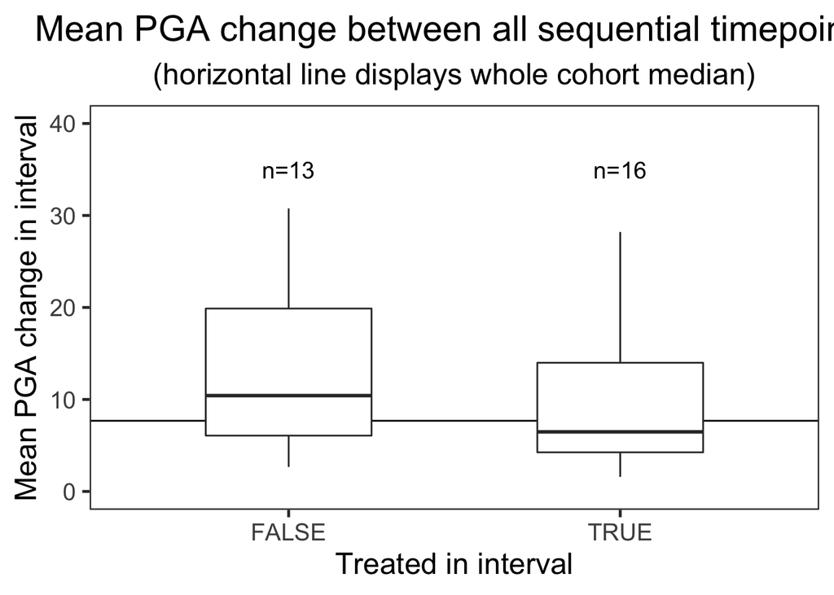

### Equivalent divergence scores for the manuscript

### Mean PGA across time

```
## [1] "Percentage points change: 3.37"
```

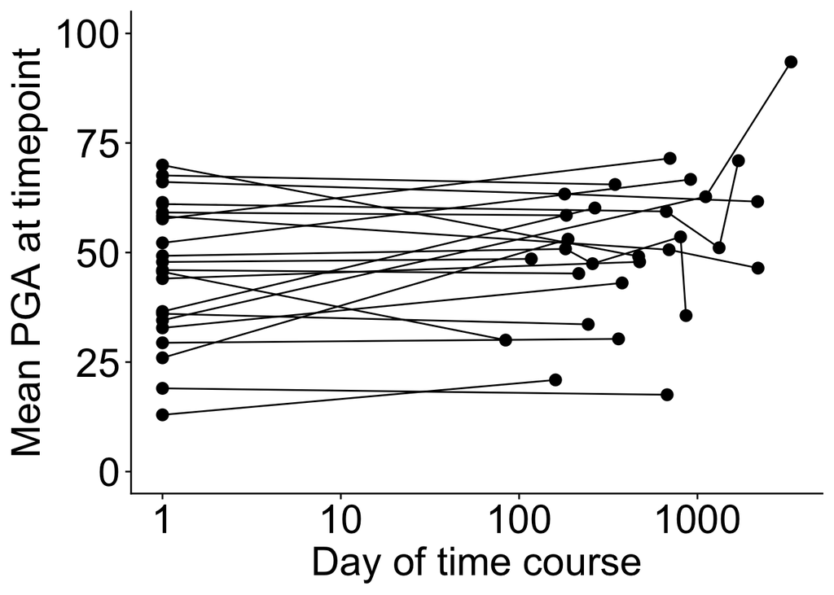

### Comparing PGA of post-timepoint 1 samples to the mean of the previous

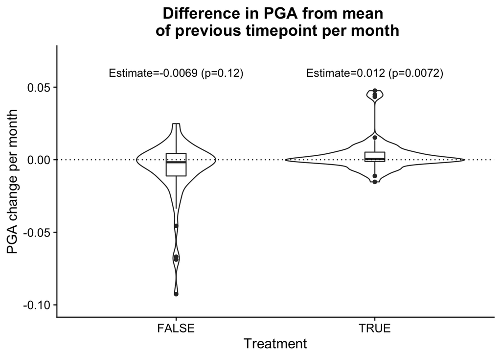

Also let’s output the PGA data etc and the classifications.